# nyc_taxi.R

josep

2023-03-18

```r
# visualisation
library('ggplot2')
library('scales')
library('grid')
library('RColorBrewer')
library('corrplot')
library('alluvial')
# data manipulation
library('dplyr')
library('data.table')
# input/output
library('readr')
# data wrangling
library('tibble')
library('tidyr')
# string manipulation
library('stringr')
# factor manipulation
library('forcats')
# date and time
library('lubridate')
# geospatial locations
library('geosphere')
# maps
library('leaflet')
library('leaflet.extras')
library('maps')

# getwd()
# setwd()
multiplot <- function(..., plotlist=NULL, file, cols=1, layout=NULL) {
  plots <- c(list(...), plotlist)
  numPlots = length(plots)
  if (is.null(layout)) {
    layout <- matrix(seq(1, cols * ceiling(numPlots/cols)),
                     ncol = cols, nrow = ceiling(numPlots/cols))
  }
  if (numPlots==1) {
    print(plots[[1]])
  } else {
    grid.newpage()
    pushViewport(viewport(layout = grid.layout(nrow(layout), ncol(layout))))
    for (i in 1:numPlots) {
      matchidx <- as.data.frame(which(layout == i, arr.ind = TRUE))
      print(plots[[i]], vp = viewport(layout.pos.row = matchidx$row,
                                      layout.pos.col = matchidx$col))
    }
  }
}
train <- as_tibble(read.csv('train.csv'))
summary(train)
```

```
##       id              vendor_id     pickup_datetime    dropoff_datetime   passenger_count
##  Length:1458644     Min.   :1.000   Length:1458644     Length:1458644     Min.   :0.000
##  Class :character   1st Qu.:1.000   Class :character   Class :character   1st Qu.:1.000
##  Mode  :character   Median :2.000   Mode  :character   Mode  :character   Median :1.000
##                     Mean   :1.535                                         Mean   :1.665
##                     3rd Qu.:2.000                                         3rd Qu.:2.000
##                     Max.   :2.000                                         Max.   :9.000
##  pickup_longitude  pickup_latitude dropoff_longitude dropoff_latitude store_and_fwd_flag
##  Min.   :-121.93   Min.   :34.36   Min.   :-121.93   Min.   :32.18    Length:1458644
##  1st Qu.: -73.99   1st Qu.:40.74   1st Qu.: -73.99   1st Qu.:40.74    Class :character
##  Median : -73.98   Median :40.75   Median : -73.98   Median :40.75    Mode  :character
##  Mean   : -73.97   Mean   :40.75   Mean   : -73.97   Mean   :40.75
##  3rd Qu.: -73.97   3rd Qu.:40.77   3rd Qu.: -73.96   3rd Qu.:40.77
##  Max.   : -61.34   Max.   :51.88   Max.   : -61.34   Max.   :43.92
##  trip_duration
##  Min.   :      1
##  1st Qu.:    397
##  Median :    662
##  Mean   :    959
##  3rd Qu.:   1075
##  Max.   :3526282
```

```r
glimpse(train)
```

```
## Rows: 1,458,644
## Columns: 11
## $ id                 <chr> "id2875421", "id2377394", "id3858529", "id3504673", "id2181028", "id0801584",…
## $ vendor_id          <int> 2, 1, 2, 2, 2, 2, 1, 2, 1, 2, 2, 2, 2, 2, 2, 1, 2, 1, 1, 2, 1, 2, 1, 1, 2, 2,…
## $ pickup_datetime    <chr> "2016-03-14 17:24:55", "2016-06-12 00:43:35", "2016-01-19 11:35:24", "2016-04…
## $ dropoff_datetime   <chr> "2016-03-14 17:32:30", "2016-06-12 00:54:38", "2016-01-19 12:10:48", "2016-04…
## $ passenger_count    <int> 1, 1, 1, 1, 1, 6, 4, 1, 1, 1, 1, 4, 2, 1, 1, 1, 1, 1, 1, 1, 1, 1, 1, 1, 1, 1,…
## $ pickup_longitude   <dbl> -73.98215, -73.98042, -73.97903, -74.01004, -73.97305, -73.98286, -73.96902, …
## $ pickup_latitude    <dbl> 40.76794, 40.73856, 40.76394, 40.71997, 40.79321, 40.74220, 40.75784, 40.7977…
## $ dropoff_longitude  <dbl> -73.96463, -73.99948, -74.00533, -74.01227, -73.97292, -73.99208, -73.95741, …
## $ dropoff_latitude   <dbl> 40.76560, 40.73115, 40.71009, 40.70672, 40.78252, 40.74918, 40.76590, 40.7605…
## $ store_and_fwd_flag <chr> "N", "N", "N", "N", "N", "N", "N", "N", "N", "N", "N", "N", "N", "N", "N", "N…
## $ trip_duration      <int> 455, 663, 2124, 429, 435, 443, 341, 1551, 255, 1225, 1274, 1128, 1114, 260, 1…
```

```r
table(train$vendor_id)
```

```
##
##      1      2
## 678342 780302
```

```r
table(train$store_and_fwd_flag)
```

```
##
##       N       Y
## 1450599    8045
```

This flag indicates whether the trip record was held in vehicle memory before sending to the vendor because the vehicle did not have a connection to the server. Y=store and forward; N=not a store and forward trip.

```r
table(train$passenger_count)
```

```
##
##       0       1       2       3       4       5       6       7       8       9
##      60 1033540  210318   59896   28404   78088   48333       3       1       1
```

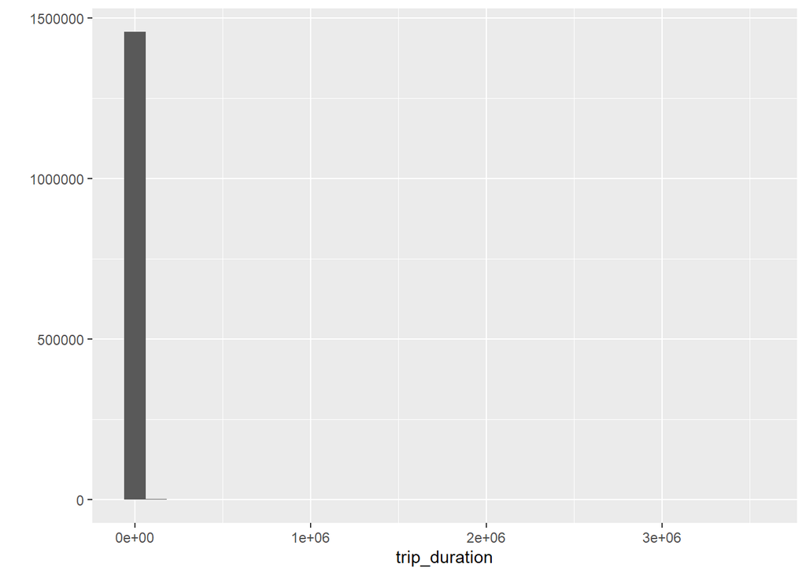

```r
qplot(trip_duration, data=train, bins = 30)
```

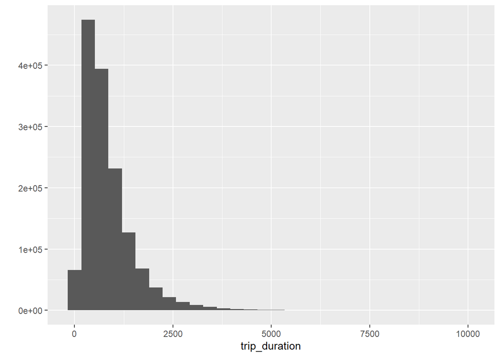

```r
t1 = train %>%
  filter(trip_duration < 10000)
qplot(trip_duration,data=t1, bins = 30)
```

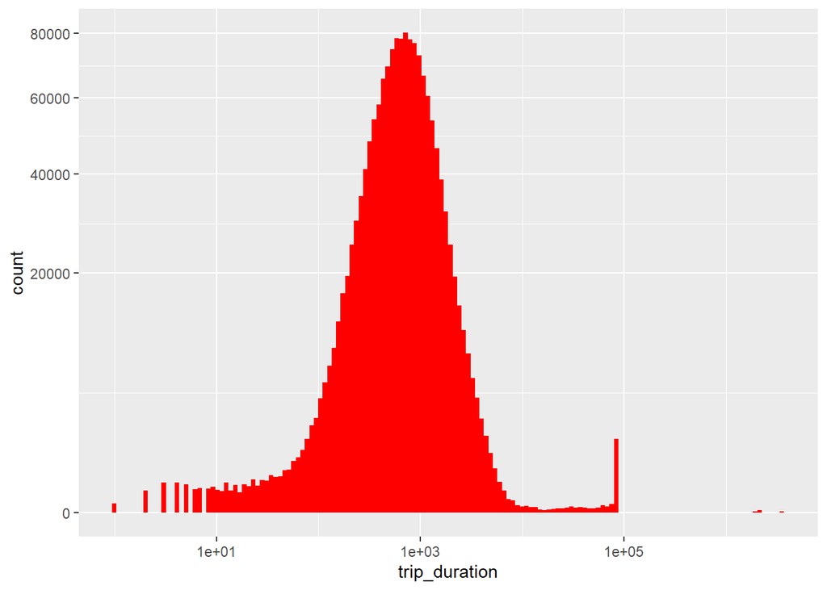

```r
train %>%
  ggplot(aes(trip_duration)) +
  geom_histogram(fill = "red", bins = 150) +
  scale_x_log10() +
  scale_y_sqrt()
```

```r
sum(is.na(train))
```

```
## [1] 0
```

```r
# Plot a map of NYC and overlay a managable number of pickup
# coordinates to get a general overview of the locations and distances in question.
# For this visualisation we use the [leaflet](https://rstudio.github.io/leaflet/)
# package, which includes a variety of cool tools for interactive maps.
# In this map you can zoom and pan through the pickup locations:


train <- train %>%
  mutate(pickup_datetime = ymd_hms(pickup_datetime),
         dropoff_datetime = ymd_hms(dropoff_datetime),
         vendor_id = factor(vendor_id),
         passenger_count = factor(passenger_count))


train %>%
  mutate(check = abs(int_length(interval(dropoff_datetime,pickup_datetime)) + trip_duration) > 0) %>%
  select(check, pickup_datetime, dropoff_datetime, trip_duration) %>%
  group_by(check) %>%
  count()
```

```
## # A tibble: 1 × 2
## # Groups:   check [1]
##   check       n
##   <lgl>   <int>
## 1 FALSE 1458644
```

```r
set.seed(1234)
foo <- sample_n(train, 8e3)
leaflet(data = foo) %>% addProviderTiles("Esri.NatGeoWorldMap") %>%
  addCircleMarkers(~ pickup_longitude, ~pickup_latitude, radius = 1,
                   color = "blue", fillOpacity = 0.3)
```

[interactive chart not shown]

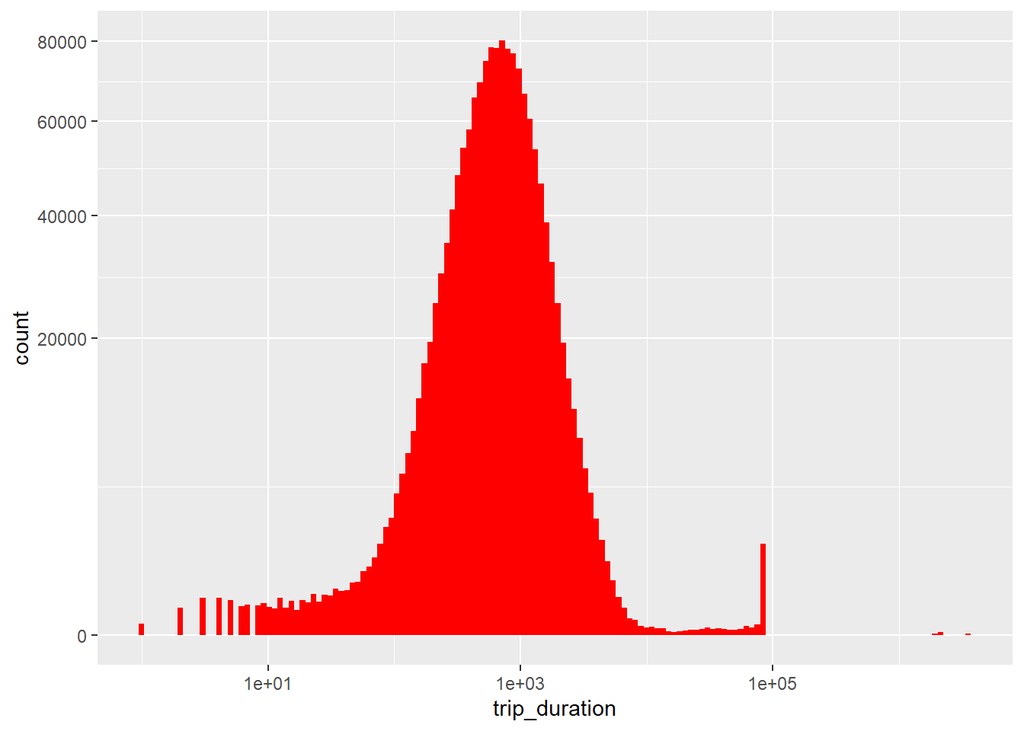

```r
# investigate the variations together with the distributions of "passenger_count" and "vendor_id" by creating a multi-plot panel with different components:

train %>%
  ggplot(aes(trip_duration)) +
  geom_histogram(fill = "red", bins = 150) +
  scale_x_log10() +
  scale_y_sqrt()
```

```r
train %>%
  arrange(desc(trip_duration)) %>%
  select(trip_duration, pickup_datetime, dropoff_datetime, everything()) %>%
  head(10)
```

```
## # A tibble: 10 × 11
##    trip_du…¹ pickup_datetime     dropoff_datetime    id    vendo…² passe…³ picku…⁴ picku…⁵ dropo…⁶ dropo…⁷
##        <int> <dttm>              <dttm>              <chr> <fct>   <fct>     <dbl>   <dbl>   <dbl>   <dbl>
##  1   3526282 2016-02-13 22:46:52 2016-03-25 18:18:14 id00… 1       1         -73.8    40.6   -74.0    40.8
##  2   2227612 2016-01-05 06:14:15 2016-01-31 01:01:07 id13… 1       1         -74.0    40.7   -74.0    40.7
##  3   2049578 2016-02-13 22:38:00 2016-03-08 15:57:38 id03… 1       2         -73.9    40.7   -74.0    40.8
##  4   1939736 2016-01-05 00:19:42 2016-01-27 11:08:38 id18… 1       1         -73.8    40.6   -74.0    40.8
##  5     86392 2016-02-15 23:18:06 2016-02-16 23:17:58 id19… 2       2         -73.8    40.6   -74.0    40.8
##  6     86391 2016-05-31 13:00:39 2016-06-01 13:00:30 id05… 2       1         -73.8    40.6   -74.0    40.7
##  7     86390 2016-05-06 00:00:10 2016-05-07 00:00:00 id09… 2       1         -74.0    40.8   -74.0    40.7
##  8     86387 2016-06-30 16:37:52 2016-07-01 16:37:39 id28… 2       1         -74.0    40.7   -74.0    40.8
##  9     86385 2016-06-23 16:01:45 2016-06-24 16:01:30 id13… 2       1         -73.8    40.6   -74.0    40.7
## 10     86379 2016-05-17 22:22:56 2016-05-18 22:22:35 id25… 2       4         -74.0    40.7   -74.0    40.8
## # … with 1 more variable: store_and_fwd_flag <chr>, and abbreviated variable names ¹trip_duration,
## #   ²vendor_id, ³passenger_count, ⁴pickup_longitude, ⁵pickup_latitude, ⁶dropoff_longitude,
## #   ⁷dropoff_latitude
```

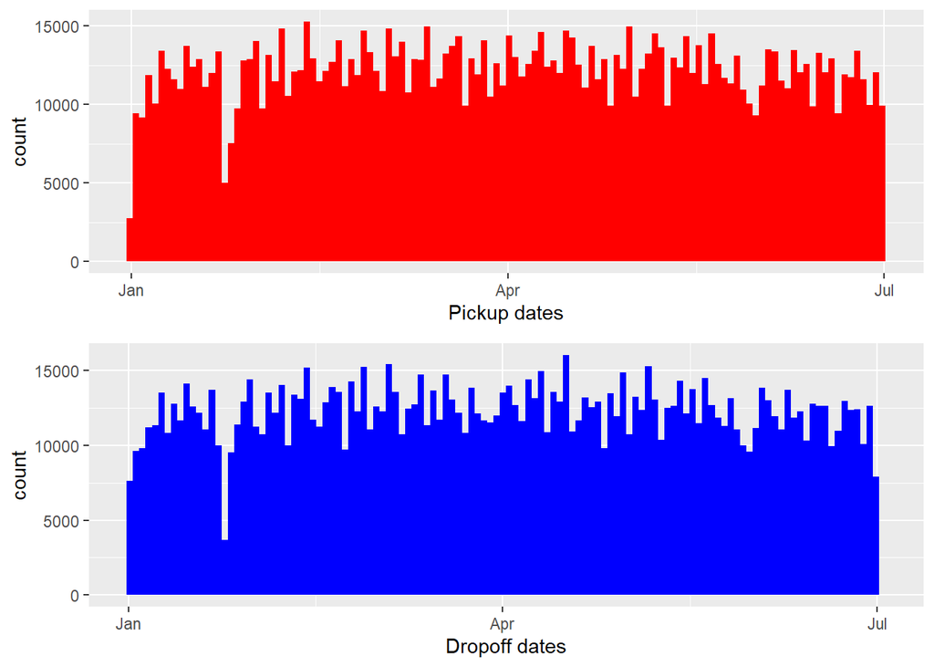

```r
p1 <- train %>%
  ggplot(aes(pickup_datetime)) +
  geom_histogram(fill = "red", bins = 120) +
  labs(x = "Pickup dates")
p2 <- train %>%
  ggplot(aes(dropoff_datetime)) +
  geom_histogram(fill = "blue", bins = 120) +
  labs(x = "Dropoff dates")
layout <- matrix(c(1,2),2,1,byrow=FALSE)
multiplot(p1, p2, layout=layout)
```

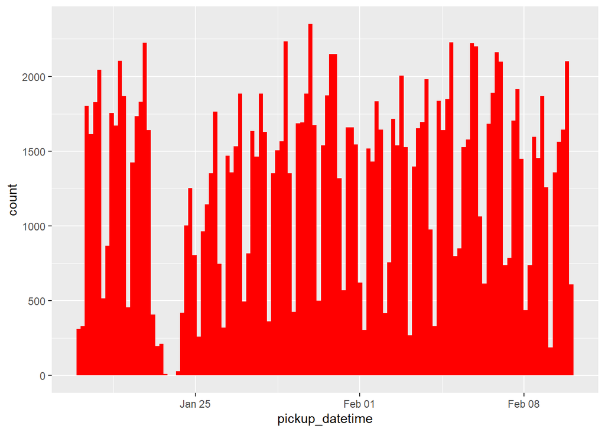

```r
p1 <- 1; p2 <- 1

train %>%
  filter(pickup_datetime > ymd("2016-01-20") & pickup_datetime < ymd("2016-02-10")) %>%
  ggplot(aes(pickup_datetime)) +
  geom_histogram(fill = "red", bins = 120)
```

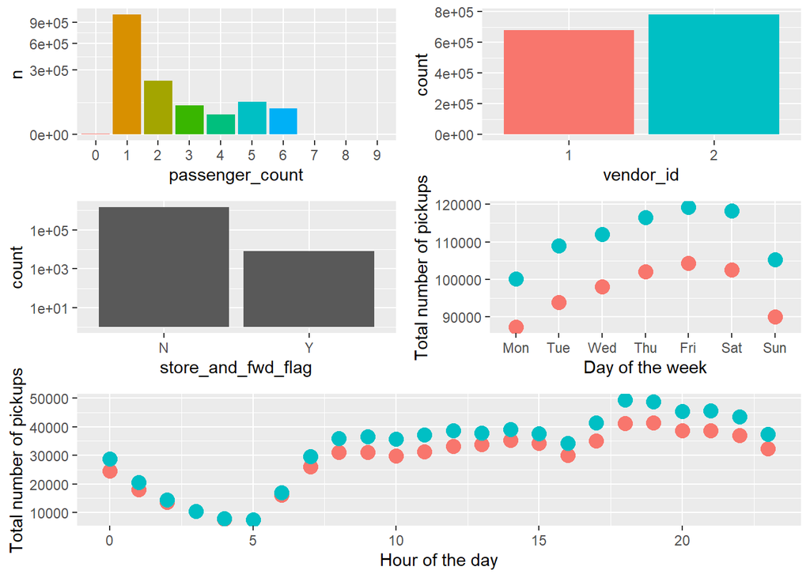

```r
# investigate the variations together with the distributions of "passenger_count"
# and "vendor_id" by creating a multi-plot panel with different components:

p1 <- train %>%
  group_by(passenger_count) %>%
  count() %>%
  ggplot(aes(passenger_count, n, fill = passenger_count)) +
  geom_col() +
  scale_y_sqrt() +
  theme(legend.position = "none")

p2 <- train %>%
  ggplot(aes(vendor_id, fill = vendor_id)) +
  geom_bar() +
  theme(legend.position = "none")

p3 <- train %>%
  ggplot(aes(store_and_fwd_flag)) +
  geom_bar() +
  theme(legend.position = "none") +
  scale_y_log10()

p4 <- train %>%
  mutate(wday = wday(pickup_datetime, label = TRUE, week_start = 1)) %>%
  group_by(wday, vendor_id) %>%
  count() %>%
  ggplot(aes(wday, n, colour = vendor_id)) +
  geom_point(size = 4) +
  labs(x = "Day of the week", y = "Total number of pickups") +
  theme(legend.position = "none")

p5 <- train %>%
  mutate(hpick = hour(pickup_datetime)) %>%
  group_by(hpick, vendor_id) %>%
  count() %>%
  ggplot(aes(hpick, n, color = vendor_id)) +
  geom_point(size = 4) +
  labs(x = "Hour of the day", y = "Total number of pickups") +
  theme(legend.position = "none")

layout <- matrix(c(1,2,3,4,5,5),3,2,byrow=TRUE)
# Most people travel as 1 passenger
# Friday was the most popular day of the week for total number of pickups
# 18:00hrs was the most popular time of the day for total number of pickups
multiplot(p1, p2, p3, p4, p5, layout=layout)
```

```r
p1 <- 1; p2 <- 1; p3 <- 1; p4 <- 1; p5 <- 1

# Check number of passengers usually in a taxi

train %>%
  group_by(passenger_count) %>%
  count()
```

```
## # A tibble: 10 × 2
## # Groups:   passenger_count [10]
##    passenger_count       n
##    <fct>             <int>
##  1 0                    60
##  2 1               1033540
##  3 2                210318
##  4 3                 59896
##  5 4                 28404
##  6 5                 78088
##  7 6                 48333
##  8 7                     3
##  9 8                     1
## 10 9                     1
```

```r
train %>%
  group_by(store_and_fwd_flag) %>%
  count()
```

```
## # A tibble: 2 × 2
## # Groups:   store_and_fwd_flag [2]
##   store_and_fwd_flag       n
##   <chr>                <int>
## 1 N                  1450599
## 2 Y                     8045
```

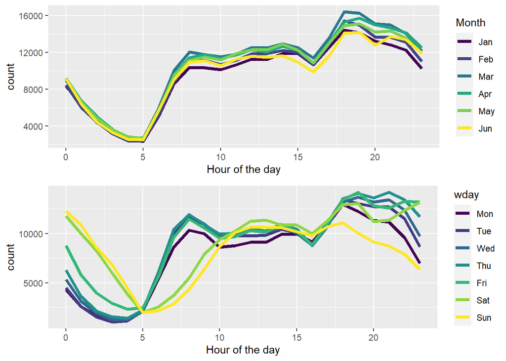

```r
# Check vendor-wise trips and the patterns for different weekdays, hours of the day, months, locations, trip duration.

p1 <- train %>%
  mutate(hpick = hour(pickup_datetime),
         Month = factor(month(pickup_datetime, label = TRUE))) %>%
  group_by(hpick, Month) %>%
  count() %>%
  ggplot(aes(hpick, n, color = Month)) +
  geom_line(size = 1.5) +
  labs(x = "Hour of the day", y = "count")
p2 <- train %>%
  mutate(hpick = hour(pickup_datetime),
         wday = factor(wday(pickup_datetime, label = TRUE, week_start = 1))) %>%
  group_by(hpick, wday) %>%
  count() %>%
  ggplot(aes(hpick, n, color = wday)) +
  geom_line(size = 1.5) +
  labs(x = "Hour of the day", y = "count")
layout <- matrix(c(1,2),2,1,byrow=FALSE)
# plot for "count" and "Hour of the day" is generally consistent throughout the months
# plot for "count" and "Hour of the day" shows different results for weekends and weekdays
multiplot(p1, p2, layout=layout)
```

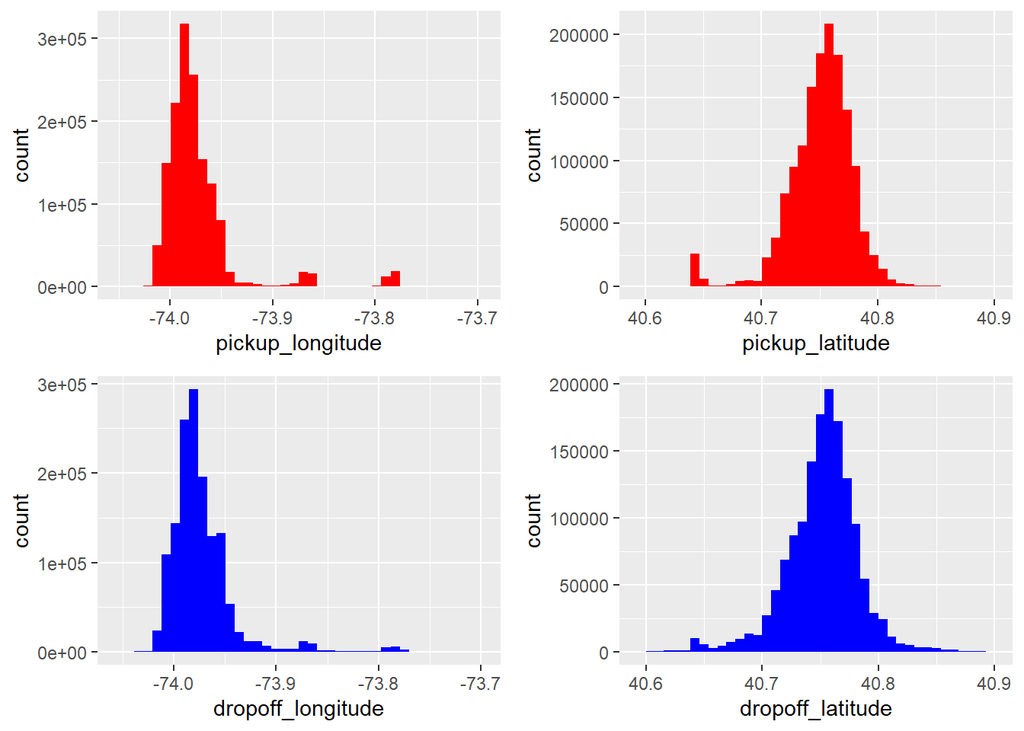

```r
p1 <- 1; p2 <- 1
p1 <- train %>%
  filter(pickup_longitude > -74.05 & pickup_longitude < -73.7) %>%
  ggplot(aes(pickup_longitude)) +
  geom_histogram(fill = "red", bins = 40)
p2 <- train %>%
  filter(dropoff_longitude > -74.05 & dropoff_longitude < -73.7) %>%
  ggplot(aes(dropoff_longitude)) +
  geom_histogram(fill = "blue", bins = 40)
p3 <- train %>%
  filter(pickup_latitude > 40.6 & pickup_latitude < 40.9) %>%
  ggplot(aes(pickup_latitude)) +
  geom_histogram(fill = "red", bins = 40)
p4 <- train %>%
  filter(dropoff_latitude > 40.6 & dropoff_latitude < 40.9) %>%
  ggplot(aes(dropoff_latitude)) +
  geom_histogram(fill = "blue", bins = 40)
layout <- matrix(c(1,2,3,4),2,2,byrow=FALSE)
multiplot(p1, p2, p3, p4, layout=layout)
```

```r
p1 <- 1; p2 <- 1; p3 <- 1; p4 <- 1
```

Check vendor-wise trips and the patterns for different weekdays, hours of the day, months, locations, trip durations.

```r
train %>%
  arrange(pickup_latitude) %>%
  select(pickup_latitude, pickup_longitude) %>%
  head(5)
```

```
## # A tibble: 5 × 2
##   pickup_latitude pickup_longitude
##             <dbl>            <dbl>
## 1            34.4            -65.8
## 2            34.7            -75.4
## 3            35.1            -71.8
## 4            35.3            -72.1
## 5            36.0            -77.4
```

```r
train %>%
  arrange(desc(pickup_latitude)) %>%
  select(pickup_latitude, pickup_longitude) %>%
  head(5)
```

```
## # A tibble: 5 × 2
##   pickup_latitude pickup_longitude
##             <dbl>            <dbl>
## 1            51.9            -72.8
## 2            44.4            -67.0
## 3            43.9            -71.9
## 4            43.5            -74.2
## 5            43.1            -72.6
```

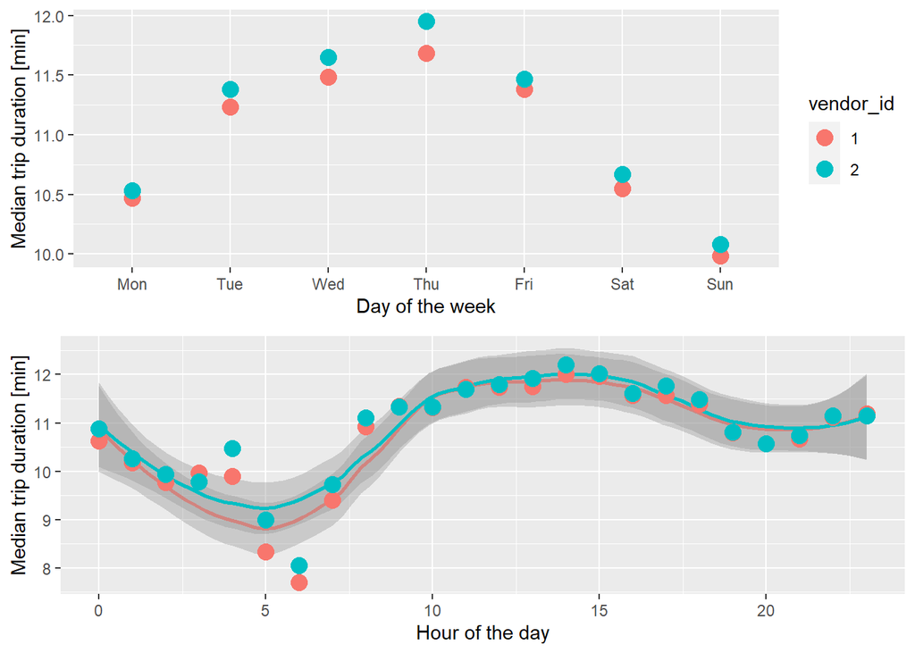

```r
p1 <- train %>%
  mutate(wday = wday(pickup_datetime, label = TRUE, week_start = 1)) %>%
  group_by(wday, vendor_id) %>%
  summarise(median_duration = median(trip_duration)/60) %>%
  ggplot(aes(wday, median_duration, color = vendor_id)) +
  geom_point(size = 4) +
  labs(x = "Day of the week", y = "Median trip duration [min]")
p2 <- train %>%
  mutate(hpick = hour(pickup_datetime)) %>%
  group_by(hpick, vendor_id) %>%
  summarise(median_duration = median(trip_duration)/60) %>%
  ggplot(aes(hpick, median_duration, color = vendor_id)) +
  geom_smooth(method = "loess", span = 1/2) +
  geom_point(size = 4) +
  labs(x = "Hour of the day", y = "Median trip duration [min]") +
  theme(legend.position = "none")
layout <- matrix(c(1,2),2,1,byrow=FALSE)
# Thursday has the longest trip duration while Sunday has the shortest
multiplot(p1, p2, layout=layout)
```

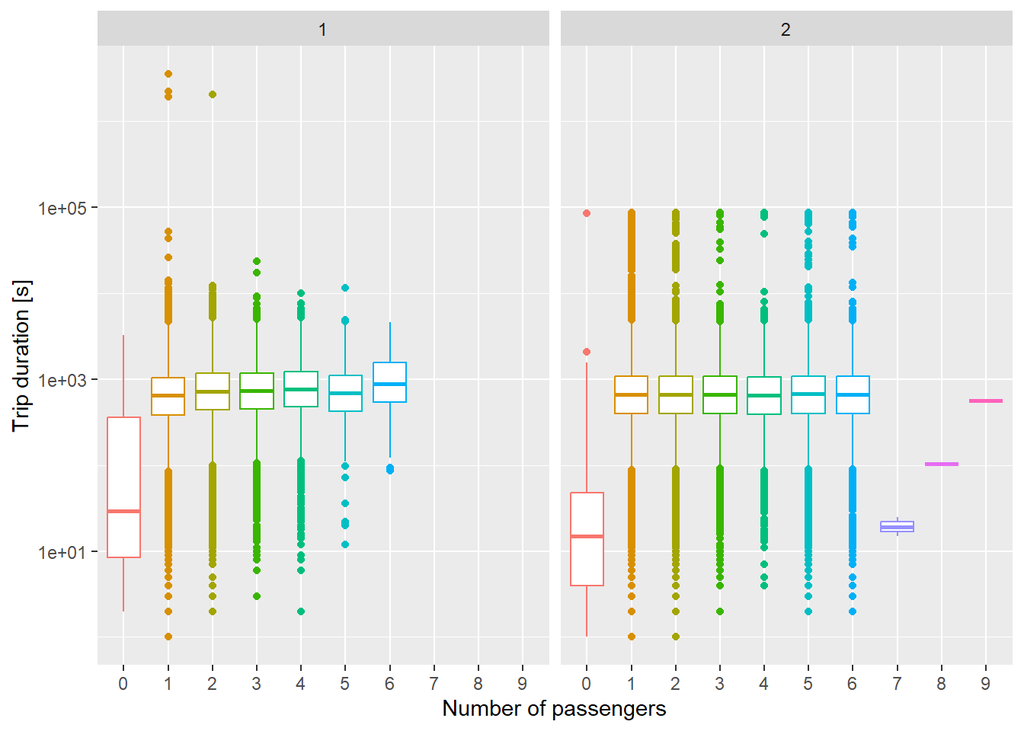

```r
p1 <- 1; p2 <- 1
# Check whether different numbers of passengers and/or
# the different vendors are correlated with the duration of the trip.
train %>%
  ggplot(aes(passenger_count, trip_duration, color = passenger_count)) +
  geom_boxplot() +
  scale_y_log10() +
  theme(legend.position = "none") +
  facet_wrap(~ vendor_id) +
  labs(y = "Trip duration [s]", x = "Number of passengers")
```

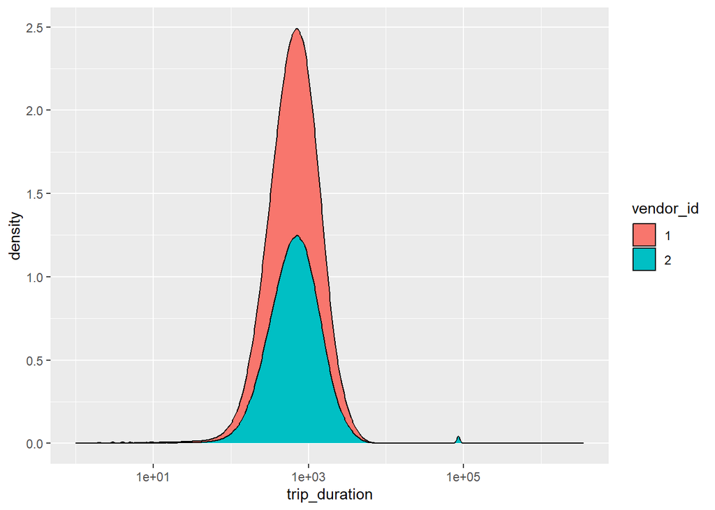

```r
  # "Number of passengers" does not have much impact on "Trip duration"

train %>%
  ggplot(aes(trip_duration, fill = vendor_id)) +
  geom_density(position = "stack") +
  scale_x_log10()
```

```r
train %>%
  group_by(vendor_id) %>%
  summarise(mean_duration = mean(trip_duration),
            median_duration = median(trip_duration))
```

```
## # A tibble: 2 × 3
##   vendor_id mean_duration median_duration
##   <fct>             <dbl>           <dbl>
## 1 1                  845.             658
## 2 2                 1059.             666
```

## Store and Forward vs “vendor_id”

```r
train %>%
  group_by(vendor_id, store_and_fwd_flag) %>%
  count()
```

```
## # A tibble: 3 × 3
## # Groups:   vendor_id, store_and_fwd_flag [3]
##   vendor_id store_and_fwd_flag      n
##   <fct>     <chr>               <int>
## 1 1         N                  670297
## 2 1         Y                    8045
## 3 2         N                  780302
```

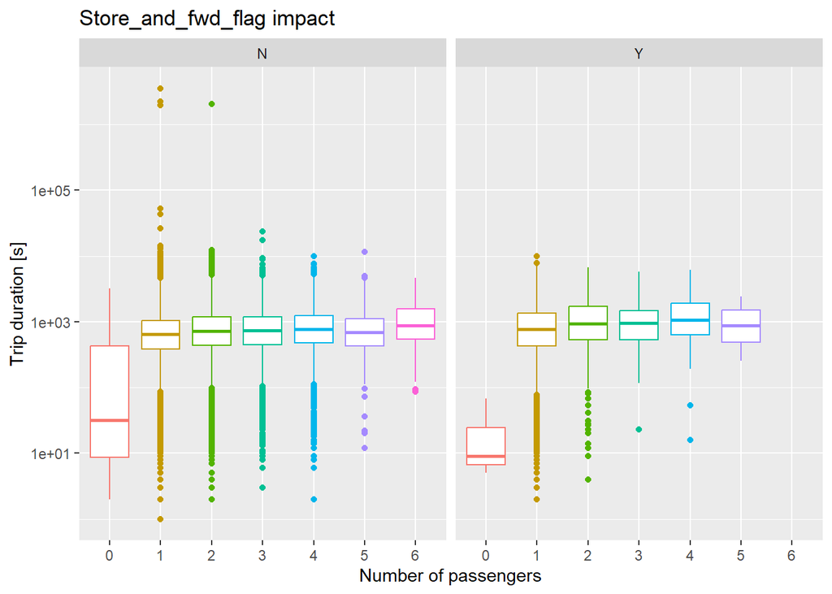

```r
train %>%
  filter(vendor_id == 1) %>%
  ggplot(aes(passenger_count, trip_duration, color = passenger_count)) +
  geom_boxplot() +
  scale_y_log10() +
  facet_wrap(~ store_and_fwd_flag) +
  theme(legend.position = "none") +
  labs(y = "Trip duration [s]", x = "Number of passengers") +
  ggtitle("Store_and_fwd_flag impact")
```

build new features from the existing ones - (date, month, wday, hour) derived from the “pickup_datetime”. #’ From the coordinates of the pickup and dropoff points calculate the direct “distance” between the two points, and compare it to our “trip_duration”, using the “distCosine” function of the [geosphere].

```r
jfk_coord <- tibble(lon = -73.778889, lat = 40.639722)
la_guardia_coord <- tibble(lon = -73.872611, lat = 40.77725)

pick_coord <- train %>%
  select(pickup_longitude, pickup_latitude)

drop_coord <- train %>%
  select(dropoff_longitude, dropoff_latitude)
train$dist <- distCosine(pick_coord, drop_coord)
train$bearing = bearing(pick_coord, drop_coord)
train$jfk_dist_pick <- distCosine(pick_coord, jfk_coord)
train$jfk_dist_drop <- distCosine(drop_coord, jfk_coord)
train$lg_dist_pick <- distCosine(pick_coord, la_guardia_coord)
train$lg_dist_drop <- distCosine(drop_coord, la_guardia_coord)

train <- train %>%
  mutate(speed = dist/trip_duration*3.6,
         date = date(pickup_datetime),
         month = month(pickup_datetime, label = TRUE),
         wday = wday(pickup_datetime, label = TRUE, week_start = 1),
         hour = hour(pickup_datetime),
         work = (hour %in% seq(8,18)) & (wday %in% c("Mon","Tues","Wed","Thurs","Fri")),
         jfk_trip = (jfk_dist_pick < 2e3) | (jfk_dist_drop < 2e3),
         lg_trip = (lg_dist_pick < 2e3) | (lg_dist_drop < 2e3),
         blizzard = !( (date < ymd("2016-01-22") | (date > ymd("2016-01-29"))) )
  )
```

compute the average apparent velocity of the taxis, the average duration per day and hour, the average speed for these time bins

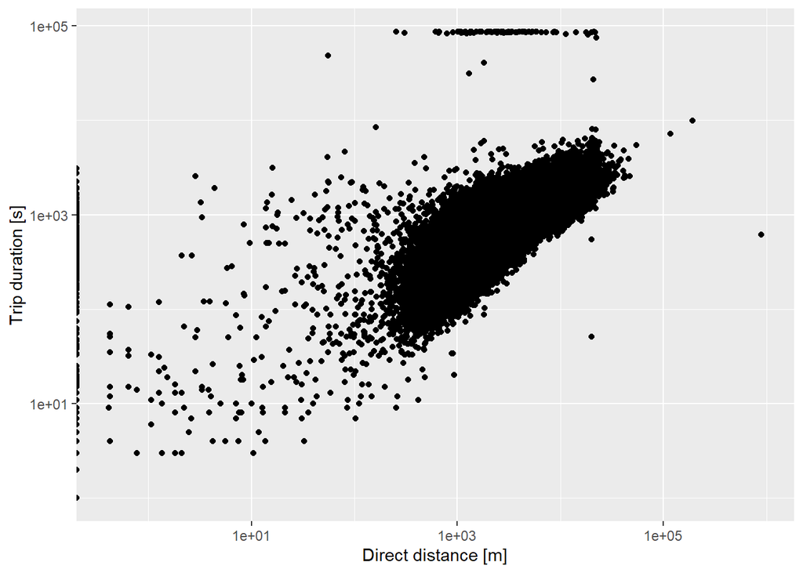

```r
set.seed(4321)
train %>%
  sample_n(5e4) %>%
  ggplot(aes(dist, trip_duration)) +
  geom_point() +
  scale_x_log10() +
  scale_y_log10() +
  labs(x = "Direct distance [m]", y = "Trip duration [s]")
```

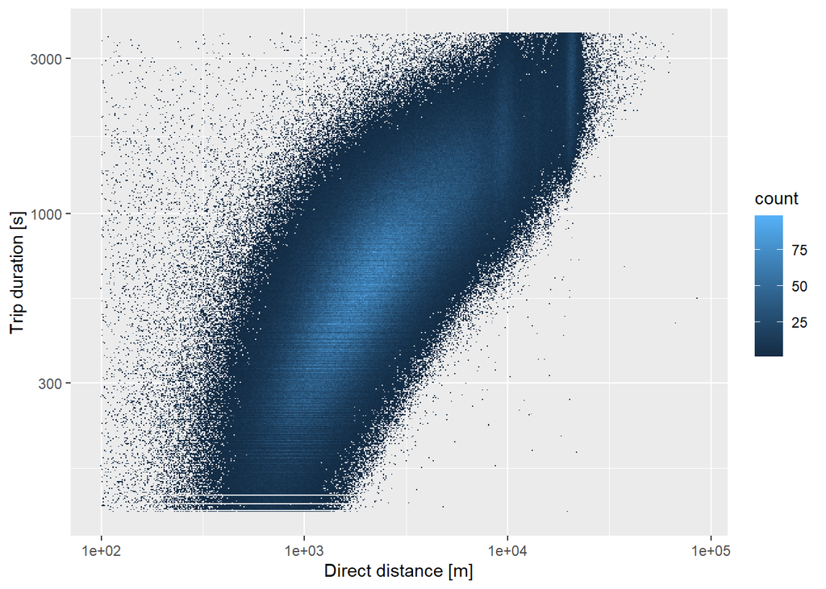

```r
train %>%
  filter(trip_duration < 3600 & trip_duration > 120) %>%
  filter(dist > 100 & dist < 100e3) %>%
  ggplot(aes(dist, trip_duration)) +
  geom_bin2d(bins = c(500,500)) +
  scale_x_log10() +
  scale_y_log10() +
  labs(x = "Direct distance [m]", y = "Trip duration [s]")
```

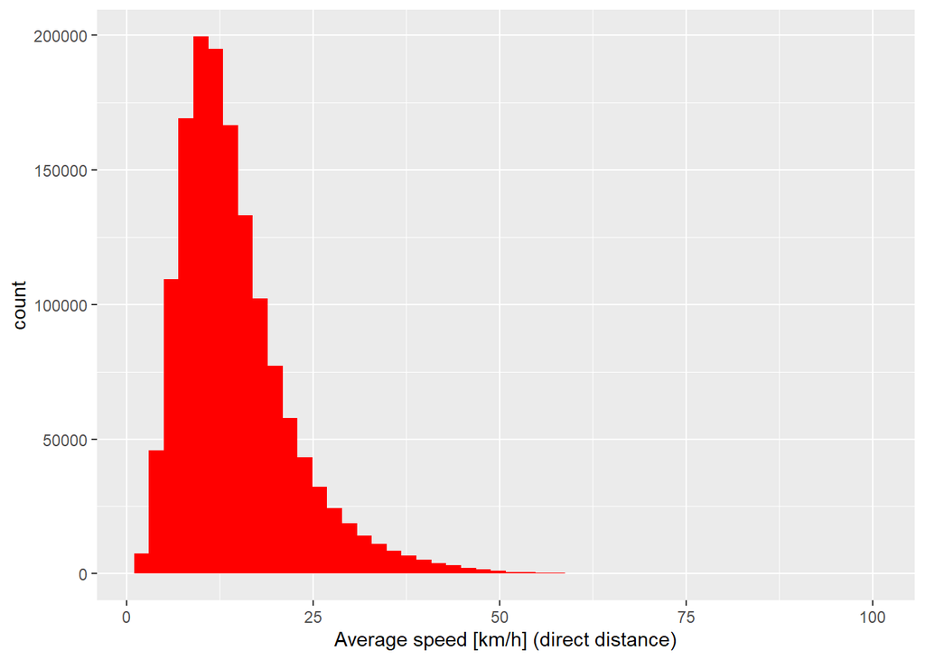

```r
train %>%
  filter(speed > 2 & speed < 1e2) %>%
  ggplot(aes(speed)) +
  geom_histogram(fill = "red", bins = 50) +
  labs(x = "Average speed [km/h] (direct distance)")
```

```r
p1 <- train %>%
  group_by(wday, vendor_id) %>%
  summarise(median_speed = median(speed)) %>%
  ggplot(aes(wday, median_speed, color = vendor_id)) +
  geom_point(size = 4) +
  labs(x = "Day of the week", y = "Median speed [km/h]")
p2 <- train %>%
  group_by(hour, vendor_id) %>%
  summarise(median_speed = median(speed)) %>%
  ggplot(aes(hour, median_speed, color = vendor_id)) +
  geom_smooth(method = "loess", span = 1/2) +
  geom_point(size = 4) +
  labs(x = "Hour of the day", y = "Median speed [km/h]") +
  theme(legend.position = "none")
```

Create heatmap of speed over the week for hours.

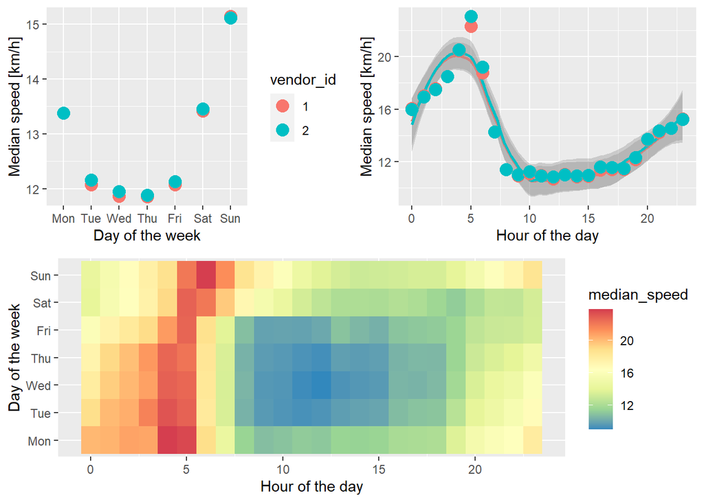

```r
p3 <- train %>%
  group_by(wday, hour) %>%
  summarise(median_speed = median(speed)) %>%
  ggplot(aes(hour, wday, fill = median_speed)) +
  geom_tile() +
  labs(x = "Hour of the day", y = "Day of the week") +
  scale_fill_distiller(palette = "Spectral")
layout <- matrix(c(1,2,3,3),2,2,byrow=TRUE)
# lower speed during the weekdays likely due to increase traffic
multiplot(p1, p2, p3, layout=layout)
```

```r
p1 <- 1; p2 <- 1; p3 <- 1
```

## Bearing direction

If the direct “distance” is the magnitude of the trip vector then the “bearing” is its (initial) direction. Easily estimated through the *geosphere* package, it tells us whether our trip started out for instance in the direction of North-West or South-East. Here we visualise the “bearing” distribution and its relation to “trip_duration”, direct “distance”, and “speed”:

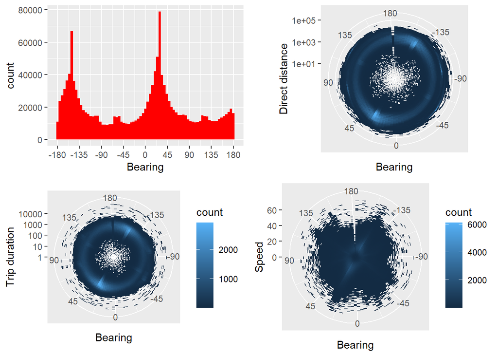

```r
p1 <- train %>%
  filter(dist < 1e5) %>%
  ggplot(aes(bearing)) +
  geom_histogram(fill = "red", bins = 75) +
  scale_x_continuous(breaks = seq(-180, 180, by = 45)) +
  labs(x = "Bearing")
p2 <- train %>%
  filter(dist < 1e5) %>%
  ggplot(aes(bearing, dist)) +
  geom_bin2d(bins = c(100,100)) +
  labs(x = "Bearing", y = "Direct distance") +
  scale_y_log10() +
  theme(legend.position = "none") +
  coord_polar() +
  scale_x_continuous(breaks = seq(-180, 180, by = 45))
p3 <- train %>%
  filter(trip_duration < 3600*22) %>%
  filter(dist < 1e5) %>%
  ggplot(aes(bearing, trip_duration)) +
  geom_bin2d(bins = c(100,100)) +
  scale_y_log10() +
  labs(x = "Bearing", y = "Trip duration") +
  coord_polar() +
  scale_x_continuous(breaks = seq(-180, 180, by = 45))
p4 <- train %>%
  filter(speed < 75 & dist < 1e5) %>%
  ggplot(aes(bearing, speed)) +
  geom_bin2d(bins = c(100,100)) +
  labs(x = "Bearing", y = "Speed") +
  coord_polar() +
  scale_x_continuous(breaks = seq(-180, 180, by = 45))
layout <- matrix(c(1,2,3,4),2,2,byrow=TRUE)
multiplot(p1, p2, p3, p4, layout=layout)
```

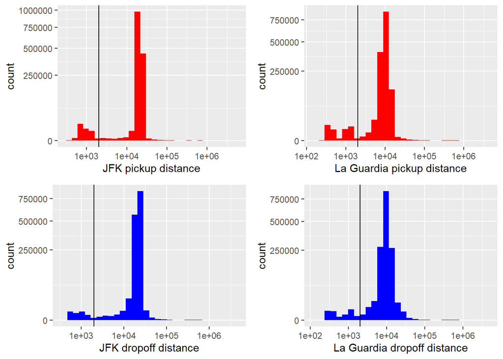

```r
p1 <- 1; p2 <- 1; p3 <- 1; p4 <- 1


p1 <- train %>%
  ggplot(aes(jfk_dist_pick)) +
  geom_histogram(bins = 30, fill = "red") +
  scale_x_log10() +
  scale_y_sqrt() +
  geom_vline(xintercept = 2e3) +
  labs(x = "JFK pickup distance")
p2 <- train %>%
  ggplot(aes(jfk_dist_drop)) +
  geom_histogram(bins = 30, fill = "blue") +
  scale_x_log10() +
  scale_y_sqrt() +
  geom_vline(xintercept = 2e3) +
  labs(x = "JFK dropoff distance")
p3 <- train %>%
  ggplot(aes(lg_dist_pick)) +
  geom_histogram(bins = 30, fill = "red") +
  scale_x_log10() +
  scale_y_sqrt() +
  geom_vline(xintercept = 2e3) +
  labs(x = "La Guardia pickup distance")
p4 <- train %>%
  ggplot(aes(lg_dist_drop)) +
  geom_histogram(bins = 30, fill = "blue") +
  scale_x_log10() +
  scale_y_sqrt() +
  geom_vline(xintercept = 2e3) +
  labs(x = "La Guardia dropoff distance")
layout <- matrix(c(1,2,3,4),2,2,byrow=FALSE)
# find out why so few people are taking taxis in particular area
multiplot(p1, p2, p3, p4, layout=layout)
```

```r
p1 <- 1; p2 <- 1; p3 <- 1; p4 <- 1; p5 <- 1

# define a JFK/La Guardia trip as having a pickup or dropoff distance of
# less than 2 km from the corresponding airport.
```

What are the “trip_durations” of these journeys?

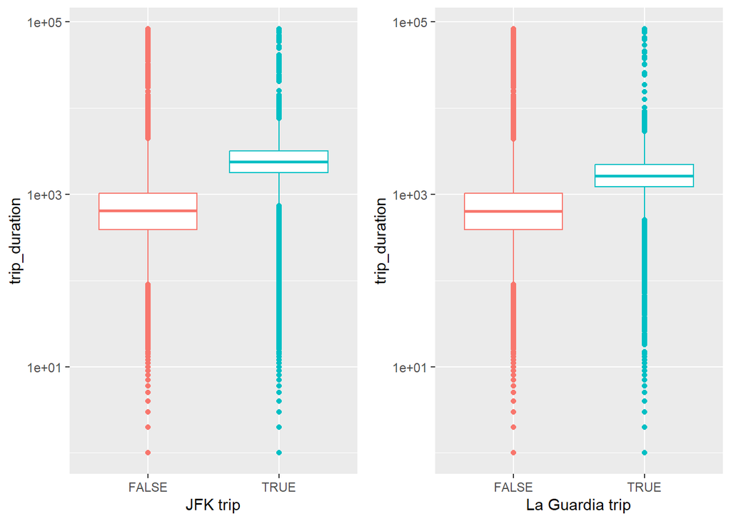

```r
p1 <- train %>%
  filter(trip_duration < 23*3600) %>%
  ggplot(aes(jfk_trip, trip_duration, color = jfk_trip)) +
  geom_boxplot() +
  scale_y_log10() +
  theme(legend.position = "none") +
  labs(x = "JFK trip")
p2 <- train %>%
  filter(trip_duration < 23*3600) %>%
  ggplot(aes(lg_trip, trip_duration, color = lg_trip)) +
  geom_boxplot() +
  scale_y_log10() +
  theme(legend.position = "none") +
  labs(x = "La Guardia trip")
layout <- matrix(c(1,2),1,2,byrow=FALSE)
multiplot(p1, p2, layout=layout)
```

```r
p1 <- 1; p2 <- 1
```

### Longer than a day

We start with the few trips that pretend to have taken several days to complete:

```r
day_plus_trips <- train %>%
  filter(trip_duration > 24*3600)
day_plus_trips %>% select(pickup_datetime, dropoff_datetime, speed)
```

```
## # A tibble: 4 × 3
##   pickup_datetime     dropoff_datetime      speed
##   <dttm>              <dttm>                <dbl>
## 1 2016-01-05 00:19:42 2016-01-27 11:08:38 0.0374
## 2 2016-02-13 22:38:00 2016-03-08 15:57:38 0.0105
## 3 2016-01-05 06:14:15 2016-01-31 01:01:07 0.00265
## 4 2016-02-13 22:46:52 2016-03-25 18:18:14 0.0203
```

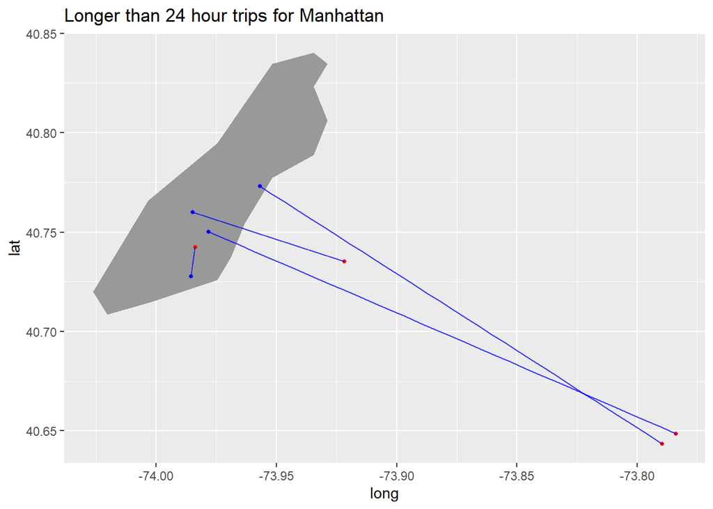

```r
ny_map <- as.tibble(map_data("state", region = "new york:manhattan"))
tpick <- day_plus_trips %>%
  select(lon = pickup_longitude, lat = pickup_latitude)
tdrop <- day_plus_trips %>%
  select(lon = dropoff_longitude, lat = dropoff_latitude)
p1 <- ggplot() +
  geom_polygon(data=ny_map, aes(x=long, y=lat), fill = "grey60") +
  geom_point(data=tpick,aes(x=lon,y=lat),size=1,color='red',alpha=1) +
  geom_point(data=tdrop,aes(x=lon,y=lat),size=1,color='blue',alpha=1)

for (i in seq(1,nrow(tpick))){
  inter <- as.tibble(gcIntermediate(tpick[i,],  tdrop[i,], n=30, addStartEnd=TRUE))
  p1 <- p1 +  geom_line(data=inter,aes(x=lon,y=lat),color='blue',alpha=.75)
}
p1 + ggtitle("Longer than 24 hour trips for Manhattan")
```

```r
p1 <- 1
```

Here we define day-long trips as taking between 22 and 24 hours, #which covers a small peak in our raw “trip_duration” distribution.

```r
day_trips <- train %>%
  filter(trip_duration < 24*3600 & trip_duration > 22*3600)
day_trips %>%
  arrange(desc(dist)) %>%
  select(dist, pickup_datetime, dropoff_datetime, speed) %>%
  head(5)
```

```
## # A tibble: 5 × 4
##     dist pickup_datetime     dropoff_datetime    speed
##    <dbl> <dttm>              <dttm>              <dbl>
## 1 60666. 2016-06-04 13:54:29 2016-06-05 13:40:30 2.55
## 2 42401. 2016-01-28 21:43:02 2016-01-29 21:33:30 1.78
## 3 28116. 2016-03-14 22:46:05 2016-03-15 22:24:27 1.19
## 4 22808. 2016-06-18 17:41:47 2016-06-19 16:30:41 1.00
## 5 22759. 2016-06-01 19:52:42 2016-06-02 19:35:09 0.960
```

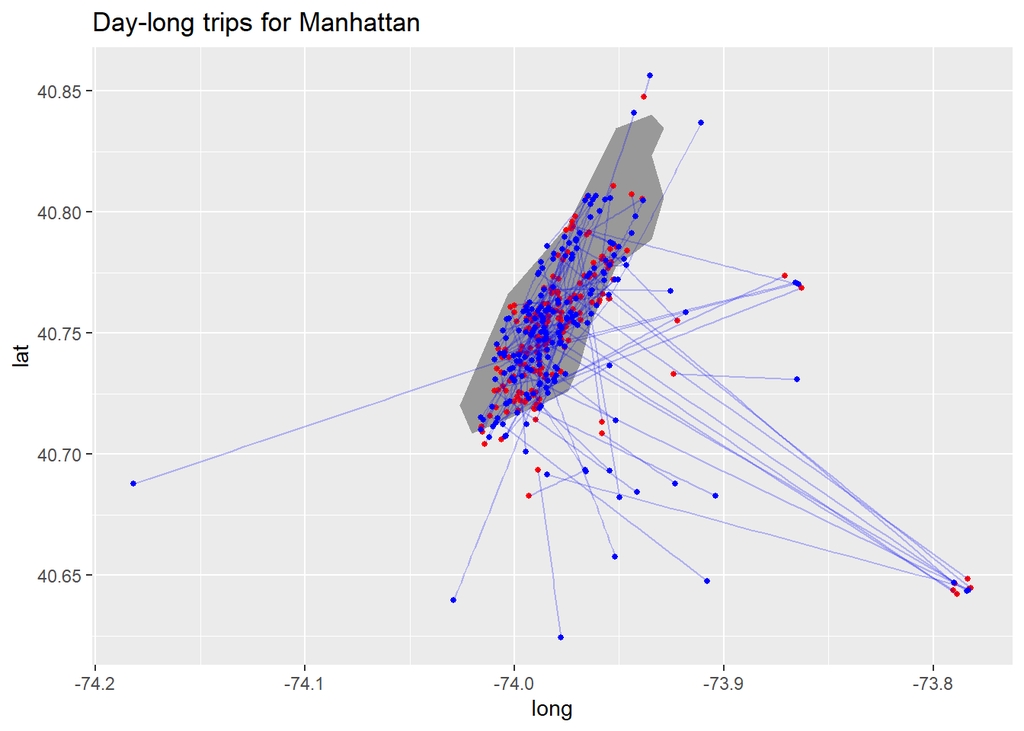

```r
ny_map <- as.tibble(map_data("state", region = "new york:manhattan"))
set.seed(2017)
day_trips <- day_trips %>%
  sample_n(200)
tpick <- day_trips %>%
  select(lon = pickup_longitude, lat = pickup_latitude)
tdrop <- day_trips %>%
  select(lon = dropoff_longitude, lat = dropoff_latitude)
p1 <- ggplot() +
  geom_polygon(data=ny_map, aes(x=long, y=lat), fill = "grey60") +
  geom_point(data=tpick,aes(x=lon,y=lat),size=1,color='red',alpha=1) +
  geom_point(data=tdrop,aes(x=lon,y=lat),size=1,color='blue',alpha=1)
for (i in seq(1,nrow(tpick))){
  inter <- as.tibble(gcIntermediate(tpick[i,],  tdrop[i,], n=30, addStartEnd=TRUE))
  p1 <- p1 +  geom_line(data=inter,aes(x=lon,y=lat),color='blue',alpha=.25)
}

p1 + ggtitle("Day-long trips for Manhattan")
```

```r
p1 <- 1

# short duration trips

min_trips <- train %>%
  filter(trip_duration < 5*60)
min_trips %>%
  arrange(dist) %>%
  select(dist, pickup_datetime, dropoff_datetime, speed) %>%
  head(5)
```

```
## # A tibble: 5 × 4
##    dist pickup_datetime     dropoff_datetime    speed
##   <dbl> <dttm>              <dttm>              <dbl>
## 1     0 2016-02-29 18:39:12 2016-02-29 18:42:59     0
## 2     0 2016-01-27 22:29:31 2016-01-27 22:29:58     0
## 3     0 2016-01-22 16:13:01 2016-01-22 16:13:20     0
## 4     0 2016-01-18 15:24:43 2016-01-18 15:28:57     0
## 5     0 2016-05-04 22:28:43 2016-05-04 22:32:51     0
```

```r
zero_dist <- train %>%
  filter(near(dist,0))
nrow(zero_dist)
```

```
## [1] 5897
```

```r
zero_dist %>%
  arrange(desc(trip_duration)) %>%
  select(trip_duration, pickup_datetime, dropoff_datetime, vendor_id) %>%
  head(5)
```

```
## # A tibble: 5 × 4
##   trip_duration pickup_datetime     dropoff_datetime    vendor_id
##           <int> <dttm>              <dttm>              <fct>
## 1         86352 2016-06-05 01:09:39 2016-06-06 01:08:51 2
## 2         85333 2016-01-01 15:27:28 2016-01-02 15:09:41 2
## 3         78288 2016-05-18 13:40:45 2016-05-19 11:25:33 2
## 4          5929 2016-06-08 16:47:44 2016-06-08 18:26:33 2
## 5          4683 2016-05-25 17:36:49 2016-05-25 18:54:52 2
```

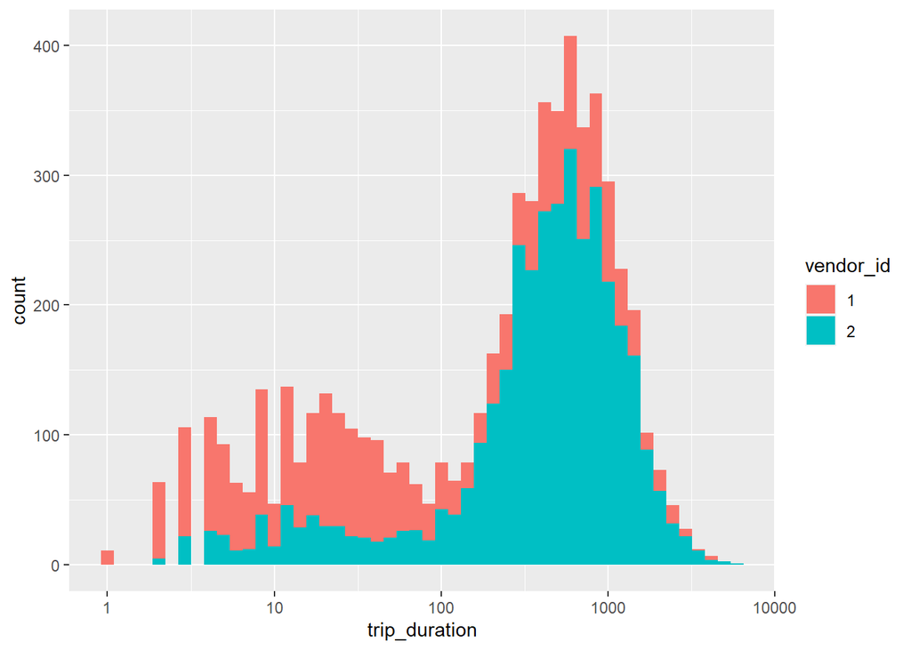

```r
zero_dist %>%
  filter(trip_duration < 6000) %>%
  ggplot(aes(trip_duration, fill = vendor_id)) +
  geom_histogram(bins = 50) +
  scale_x_log10()
```

```r
#### Short trips with above zero distance
```

After removing the zero-distance trips, those are the short rides with the highest average speed:

```r
min_trips <- train %>%
  filter(trip_duration < 5*60 & dist > 0)

min_trips %>%
  arrange(desc(speed)) %>%
  select(trip_duration, dist, pickup_datetime, speed) %>%
  head(10)
```

```
## # A tibble: 10 × 4
##    trip_duration    dist pickup_datetime     speed
##            <int>   <dbl> <dttm>              <dbl>
##  1             7  18055. 2016-02-13 20:28:30 9285.
##  2           282 320484. 2016-04-02 20:33:19 4091.
##  3             2    784. 2016-06-12 06:35:13 1412.
##  4            51  19970. 2016-06-19 20:18:35 1410.
##  5           279 104877. 2016-03-20 21:07:56 1353.
##  6             2    704. 2016-06-23 13:36:48 1267.
##  7            20   6919. 2016-05-28 15:14:19 1245.
##  8             3    914. 2016-05-30 17:12:12 1097.
##  9             4   1031. 2016-01-17 03:11:56  928.
## 10             3    762. 2016-06-13 16:34:30  914.
```

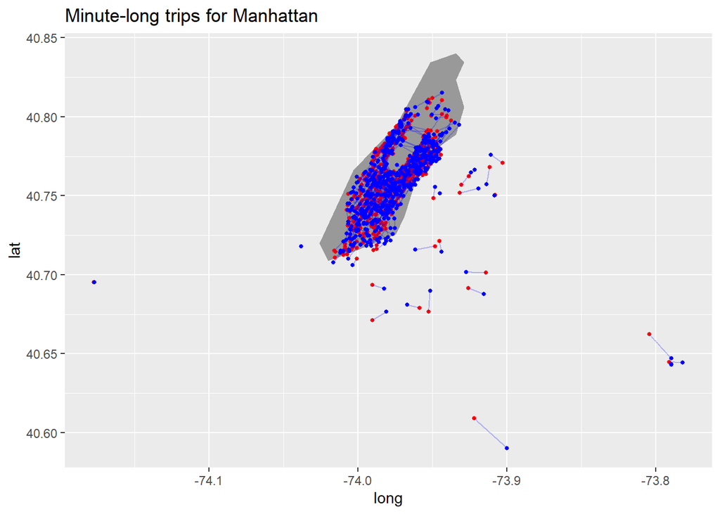

```r
# plot the general distribution of distances within the sample-

ny_map <- as.tibble(map_data("state", region = "new york:manhattan"))
set.seed(1234)

foo <- min_trips %>%
  sample_n(600)

tpick <- foo %>%
  select(lon = pickup_longitude, lat = pickup_latitude)

tdrop <- foo %>%
  select(lon = dropoff_longitude, lat = dropoff_latitude)

p1 <- ggplot() +
  geom_polygon(data=ny_map, aes(x=long, y=lat), fill = "grey60") +
  geom_point(data=tpick,aes(x=lon,y=lat),size=1,color='red',alpha=1) +
  geom_point(data=tdrop,aes(x=lon,y=lat),size=1,color='blue',alpha=1)

for (i in seq(1,nrow(tpick))){
  inter <- as.tibble(gcIntermediate(tpick[i,],  tdrop[i,], n=30, addStartEnd=TRUE))
  p1 <- p1 +  geom_line(data=inter,aes(x=lon,y=lat),color='blue',alpha=.25)
}

p1 + ggtitle("Minute-long trips for Manhattan")
```

```r
p1 <- 1

# Explore long distance Trips :
# with pickup or dropoff locations more than 300 km away from NYC (JFK airport)
long_dist <- train %>%
  filter( (jfk_dist_pick > 3e5) | (jfk_dist_drop > 3e5) )

long_dist_coord <- long_dist %>%
  select(lon = pickup_longitude, lat = pickup_latitude)

long_dist %>%
  select(id, jfk_dist_pick, jfk_dist_drop, dist, trip_duration, speed) %>%
  arrange(desc(jfk_dist_pick))
```

```
## # A tibble: 31 × 6
##    id        jfk_dist_pick jfk_dist_drop      dist trip_duration     speed
##    <chr>             <dbl>         <dbl>     <dbl>         <int>     <dbl>
##  1 id2854272      4128727.      4128719.      14.8           499    0.107
##  2 id3777240      4128721.      4128726.      21.8          1105    0.0711
##  3 id2306955      1253574.        21484. 1242299.            792 5647.
##  4 id1974018      1115646.      1115646.       0             369    0
##  5 id0267429       988748.       988748.       0             961    0
##  6 id0838705       695767.       481141.  215468.           1131  686.
##  7 id0205460       684133.       684133.       0             329    0
##  8 id0978162       674251.       941618.  315117.            875 1296.
##  9 id3525158       665877.       665877.       0             385    0
## 10 id1510552       642663.       472020.  892212.            611 5257.
## # … with 21 more rows
```

```r
# plot zero-distance trips with more than a minute duration.

leaflet(long_dist_coord) %>%
  addTiles() %>%
  setView(-92.00, 41.0, zoom = 4) %>%
  addProviderTiles("CartoDB.Positron") %>%
  addMarkers(popup = ~as.character(long_dist$dist), label = ~as.character(long_dist$id))
```

[interactive chart not shown]

```r
# Explore 0 distance Trips

train <- train %>%
  filter(trip_duration < 22*3600,
         dist > 0 | (near(dist, 0) & trip_duration < 60),
         jfk_dist_pick < 3e5 & jfk_dist_drop < 3e5,
         trip_duration > 10,
         speed < 100)
```